# R-kundungstour

Fundamente der Umweltdatenverarbeitung

Elena Macdonald

# 1 Legende

Die folgende Notation wird in diesem Dokument benutzt:

R Code (den Du über copy & paste in Euer Script überführen und ausführen kannst) wird so dargestellt:

```r
R_Code() # Raute ("Hashtag") kennzeichnet einen Kommentar; wird von R ignoriert = nicht ausgeführt
```

Die Ausgabe von Befehlen in R wird hier so dargestellt:

```
## [1] "Die Ausgabe eines R-Befehls"
```

Aufgaben zu den einzelnen Kapiteln werden eingerückt dargestellt:

> Simple Aufgabe

> Klicke den Button, um die Lösung aufzuklappen!

> Hier steht dann die Lösung.

# 2 Hallo R!

R ist eine interpretierte Sprache - so wie auch Python oder Matlab. Im Gegensatz zu kompilierten Sprachen (so wie C, C++ oder Fortran) wird jedes Kommando sofort ausgeführt (“interpretiert”).

Die Ausführung erfolgt in RStudio, indem man sich mit dem Cursor auf eine ausführbare Zeile bewegt und dann in der Toolbar den `Run`-Button drückt. Alternative: `Strg + Enter`.

**Beispiel** Wir nutzen den `print`-Befehl, um eine Ausgabe im “Hallo Welt”-Stil zu erzeugen (traditionell die erste Operation beim Erlernen einer Programmiersprache). Führt dazu folgende Zeile wie beschrieben aus!

```r
print("Hallo R!")
```

```
## [1] "Hallo R!"
```

> Aufgabe 1

> Schreibe Dein eigenes “Hallo”-Statement und führe es aus.

# 3 R als Taschenrechner

Du weißt nun, wie man eine Zeile ausführt. Anstatt jetzt einen `print`-Befehl auszuführen, könnt Ihr auch einfache Rechenoperationen ausführen. Das Ergebnis der Operation gibt RStudio direkt aus.

```r
1+1
```

```
## [1] 2
```

```r
2**3
```

```
## [1] 8
```

> Aufgabe 2

> Berechne das Ergebnis der Operation $(\frac{22}{11} * (1 + 5))^2$

> ```r
> (22/11 * (1+5))^2
> ```

> ```
> ## [1] 144
> ```

# 4 Arbeitsschritte speichern

Du kannst alles, was Du in einer R-Sitzung an Befehlen benutzt, auch speichern, um später daran weiterzuarbeiten oder eine Analyse zu wiederholen. Dies betrifft nur die Befehle; etwaige Daten oder Zwischenergebnisse werden dann wieder neu erzeugt.

## 4.1 Speichern als R-Skript

Die einfachere Art, wenn es primär darum geht, Deinen Quelltext zu sichern: Einfach unter “Datei”-> “Speichern unter…” speichern. Mit dem erneuten Öffnen von RStudio werden die letzten Dateien meist gleich mitgeöffnet.

## 4.2 Markdown in R

Markdown kennst Du vielleicht schon aus der Lektion “git-together”. Ein schlanke Sprache, um übersichtlich formatierten Text zu erstellen. Mit der [Markdown-Synthax](https://www.markdownguide.org/basic-syntax/) lassen sich eine vielzahl von Formatierungen umsetzen.

Auch in R kannst Du Markdown-Dateien erstellen und dann “rendern” (also hübsch formatiert darstellen). Dafür gehst Du in RStudio unter `File` auf `New File` und klickst dort auf `R Markdown...`. Ein Fenster öffnet sich, in dem Du Titel, Autor und das standardmäßige Output-Format angeben kannst. Nachdem Du auf `OK` klickst, wird eine Rmd-Datei erstellt, die schon einige grundlegende Infos und Beispiel-Befehle für R-Markdown enthält. Wenn Du nun auf den `Knit`-Button klickst, wird eine HTML-Datei erzeugt, die sowohl formatierten Text als auch Code-Blöcke enthält. Das geht dann so:

`` ```{r, include=TRUE, eval=TRUE} (22/11 * (1+5))^2 ``` ``

Je nach Optionen in den geschweiften Klammern werden diese Blöcke dann mit Quellcode dargestellt und/oder ausgeführt und in das Dokument eingebunden.

> Aufgabe 3

> Füge der Markdown-Datei folgende Elemente hinzu:  
> (i) eine weitere Überschrift,  
> (ii) eine Liste mit drei Elementen,  
> (iii) eine weitere Codeblockzeile, die “Hallo” ausgibt,  
> (iv) einen weiteren funktionierenden Hyperlink.

> `# Eine weitere Überschrift`

# Eine weitere Überschrift

> `* ein Element * noch eines * und Nummer Drei`
> - ein Element
> - noch eines
> - und Nummer Drei

> `` ```{r, include=TRUE, eval=TRUE} print("Hello again!") ``` ``

> ```r
> print("Hello again!")
> ```

> ```
> ## [1] "Hello again!"
> ```

> `[Link zu nerdigen Cartoons](https://xkcd.com/)`

> [Link zu nerdigen Cartoons](https://xkcd.com/)

# 5 Mit Variablen arbeiten

Die Zuweisung von Variablen und das Arbeiten mit diesen Variablen ist ein wesentliches Element der Programmierung. Wir kennen das Konzept der Zuweisung aus der Mathematik:

```r
a <- 1
b <- 1
c <- a + b
# Die folgende Zeile sorgt dafür, dass der Wert von c ausgegeben wird.
c
```

```
## [1] 2
```

Anstelle der Zuweisung `<-` akzeptiert R auch ein einigen vielleicht intuitiver erscheinendes `=`. Beides hat Vor- und Nachteile; beides funktioniert.

Im Prinzip ist das Zuweisen von Variablenwerten und das Arbeiten mit Variablen intuitiv. Für Neulinge mag aber überraschend sein, dass die Zuweisung sich nicht auf numerische Werte beschränken muss.

```r
# Zuweisung einer Zeichenkette
a <- "Rosalind"
b <- "Franklin"
a
```

```
## [1] "Rosalind"
```

```r
b
```

```
## [1] "Franklin"
```

Zeichenketten lassen sich in R mit `paste` zusammenfügen.

```r
paste(a,b)
```

```
## [1] "Rosalind Franklin"
```

> Aufgabe 4

> Recherchiere, wer Rosalind Franklin war.

Es gibt unterschiedliche Datentypen, die wir zuweisen können. Den Datentyp einer Variable können wir über den `class` Befehl abfragen:

```r
a <- 1
b <- "Rosalind"
c <- 1.5
d <- TRUE

class(a)
## [1] "numeric"
class(b)
## [1] "character"
class(c)
## [1] "numeric"
class(d)
## [1] "logical"
```

Einige Datentypen kann man durch Operationen sinnvoll verknüpfen, andere nicht.

> Aufgabe 5

> Verknüpfe die Variablen `a`, `b`, `c` und `d` jeweils paarweise mit dem `+`-Operator. Erläutere Deine Beobachtungen.

> ```r
> a+b
> ```

> ```
> ## Error in a + b: nicht-numerisches Argument für binären Operator
> ```

> ```r
> a+c
> ```

> ```
> ## [1] 2.5
> ```

> ```r
> a+d
> ```

> ```
> ## [1] 2
> ```

> ```r
> b+c
> ```

> ```
> ## Error in b + c: nicht-numerisches Argument für binären Operator
> ```

> ```r
> b+d
> ```

> ```
> ## Error in b + d: nicht-numerisches Argument für binären Operator
> ```

> ```r
> c+d
> ```

> ```
> ## [1] 2.5
> ```

# 6 Selber machen lassen: Die Lösung kommt als Paket

Man kann sich für alle Anwendungsfälle eine eigene Lösung zurechtprogrammieren. Oft haben andere das aber schon besser gemacht. Das Ergebnis kann man sich als “Paket” (package) (Synonym: Bibliothek/library) importieren und direkt nutzen. Es gibt Pakete für alles: numerische Operationen, Dateisystemoperationen, Grafikerstellung, Statistik - es gibt fast nichts, was es fast nicht gibt.

**Beispiel**: Wir installieren und laden das `sessioninfo`-Paket. Damit kann man Informationen über die aktuelle R-Session abfragen und anzeigen lassen.

```r
# Paket installieren
install.packages("sessioninfo")
# Paket laden
library(sessioninfo)
```

Das war’s schon. Wir überprüfen mal eine Funktion, die uns `sessioninfo` zur Verfügung stellt und lassen uns Informationen über die verwendete Plattform ausgeben:

```r
sessioninfo::platform_info()
```

```
##  setting  value
##  version  R version 4.2.2 (2022-10-31 ucrt)
##  os       Windows 10 x64 (build 19045)
##  system   x86_64, mingw32
##  ui       RTerm
##  language (EN)
##  collate  German_Germany.utf8
##  ctype    German_Germany.utf8
##  tz       Europe/Berlin
##  date     2023-10-27
##  pandoc   2.19.2 @ C:/Program Files/RStudio/resources/app/bin/quarto/bin/tools/ (via rmarkdown)
```

Die Angaben unter *value* sehen bei Dir möglicherweise etwas anders aus. Falls Du mit einigen Angaben unter *setting* nichts anfangen kannst (Wofür steht zum Beispiel *ui*?), kann man in der Dokumentation des Paketes nachschauen, welche Werte einem die Funktion eigentlich ausspuckt. Darauf werden wir später in der Lektion noch eingehen, wenn wir uns mit dem Suchen und Finden von Hilfe beschäftigen. Wichtig für Dich ist jetzt vor allem: Die Funktionen eines importierten Paketes kann man mit `paketname::funktionsname` ansprechen. Wenn man wie oben das Paket mit `library` geladen hat, recht auch der Funktionsname allein - solange es keine Namensvettern in gleichzeitig geladenen Paketen gibt. Mehr zu Funktionen dann später!

# 7 Auf Dateien zugreifen

Das Arbeiten mit Daten beinhaltet meist den Zugriff auf Dateien, welche diese Daten bereitstellen. Das Lesen und Schreiben von Daten bzw. Dateien ist naturgemäß eine zentrale Komponente der Datenverarbeitung. Zwei Aspekte sind dabei wichtig:

- Wo befindet sich eine Datei?
- Mit was für einem Inhalt rechne ich? Hier kommen die Begriffe “Dateiformat” und “Datenmodell” ins Spiel: Ein Dateiformat wäre z.B. eine Textdatei, ein Datenmodell wäre eine Tabelle. Eine csv-Datei ist z.B. typischerweise eine Textdatei mit einer Tabelle, in der die Spalten mit einem Komma oder einem Semikolon getrennt sind. Eine xlsx-Datei wiederum ist eine binäre Datei, die wiederum eine Tabelle enthält. Mehr dazu in Lektion 5.

## 7.1 Wo befindet sich die Datei, die ich lesen oder schreiben möchte?

Der Speicherort einer Datei wird über den “Pfad” angegeben. Man unterscheidet zwischen “absoluten” und “relativen” Pfadangaben. Der relative Pfad gibt den Speicherort *relativ* zum Arbeitsverzeichnis an.

Das aktuelle Arbeitsverezichnis kann man sich über `getwd()` (get working directory) anzeigen lassen und über `setwd()` (set working directory) neu festlegen

```r
# Arbeitsverzeichnis anzeigen lassen
getwd()

# Arbeitsverzeichnis neu festlegen
setwd("D:/emac/Documents/Lehre/UmweltDV/01_environment")
```

Bei Pfadangaben in R ist es wichtig, *forward slashes* (“/”) und keine *backslashes* (“\”, was die typische Windows-Schreibweise bei Pfadangaben ist) zu nutzen.

> Aufgabe 6

> Lege als Arbeitsverzeichnis den Ordner fest, in dem Dein R-Skript gespeichert ist. Das kannst Du entweder über `setwd()` machen oder über das `Session`-Menü in der Funktionsleiste oben: `Session` > `Set Working Directy` > `To Source File Location`.

### 7.1.1 Relative Pfadangaben

Versuchen wir nun einmal, eine Datei im aktuellen Verzeichnis zu lesen. Wir nutzen dazu den Befehl `read.table`

```r
read.table("example-file-1.txt", sep="\n")
```

```
##                                                   V1
## 1                                        Hallo Welt!
## 2 (in einer Datei im gleichen Verzeichnis versteckt)
```

Das Argument `sep` teilt R mit, wodurch verschiedene Einträge in der Datei voneinander getrennt sind (z.B. durch Leerzeichen, Kommata etc.). Da wir keine Tabelle mit mehreren Einträgen in Zeilen oder Spalten einlesen wollen, müssen wir R mitteilen, dass es keinen *field separator* gibt.

Nun öffnen wir die Datei `example-file-2.txt`, die in dem Unterverzeichnis `data` relativ zu unserem Arbeitsverzeichnis liegt.

```r
read.table("data/example-file-2.txt", sep="\n")
```

```
##                                                    V1
## 1                                  Hallo andere Welt!
## 2 (in einer Datei im Unterverzeichnis data versteckt)
```

Aller guten Dinge sind drei: Nun greifen wir über einen relativen Pfad auf eine Datei zu, die nicht in unserem Arbeitverzeichnis liegt, sondern in dem `data`-Verzeichnis, welches eine Ebene darüber liegt. Übergeordnete Verzeichnisebenen spricht man mit dem `..`-Element an.

```r
read.table("../data/example-file-3.txt", sep="\n")
```

[output not shown]

### 7.1.2 Absolute Pfadangaben

Bislang haben wir immer relative Pfadangaben (relativ zum Arbeitsverzeichnis) genutzt. Wenn man auf Dateien zugreifen möchte, die auf dem Rechner “weit weg” vom Arbeitsverzeichnis liegen, können solche relativen Pfade aber sehr mühsam umzusetzen sein. Man kann auch einfach den vollständigen (absoluten) Pfad zu einer Datei angeben. Dieser ist dann aber auf jedem System anders, weil jeder auf seinem Rechner andere Verzeichnisstrukturen hat. Der absolute Pfad zu meiner Datei `example-file-1.txt` lautet zum Beispiel: `D:/emac/Documents/Lehre/UmweltDV/01_environment/example-file-1.txt`.

> Aufgabe 7

> Wie lautet der absolute Pfad zu dieser Datei auf Deinem System? Lies den Dateiinhalt unter Nutzung einer absoluten Pfadangabe.

## 7.2 Wie ich die Datei öffne, hängt vom Inhalt ab, den ich erwarte!

Wir haben eben bereits Textdateien eingelesen. Dabei haben wir einfach den gesamten Inhalt komplett ausgegeben. Meist wollen wir den Dateiinhalt jedoch interpretieren. Oft wird in Textdateien eine Tabelle abgelegt, deren Spalten mit Zeichen wie `;` oder `,` getrennt sind.

Lesen wir statt einer txt-Datei doch mal eine csv-Datei ein.

```r
df <- read.table("../data/example-table.csv", sep=";", header=TRUE)
df
```

```
##    temperature saturation
## 1          -30       0.51
## 2          -20       1.26
## 3          -10       2.87
## 4           -5       4.22
## 5            0       6.11
## 6            5       8.72
## 7           10      12.26
## 8           15      17.02
## 9           20      23.33
## 10          25      31.60
## 11          30      42.34
## 12          35      56.13
```

Die zusätzliche Angabe `header=TRUE` bedeutet lediglich, dass die Einträge der ersten Zeile als Spaltennamen interpretiert werden sollen.

Im nächsten Termin wirst Du mehr über das Einlesen und Arbeiten mit solchen *Dataframes* lernen.

# 8 Grafiken erstellen

In diesem Kurs werden wir uns noch oft und ausführlich mit der Erstellung von Grafiken beschäftigen. Jetzt nur ganz kurz, weil wir gerade schonmal Daten aus einer Tabelle im Arbeitsspeicher haben…

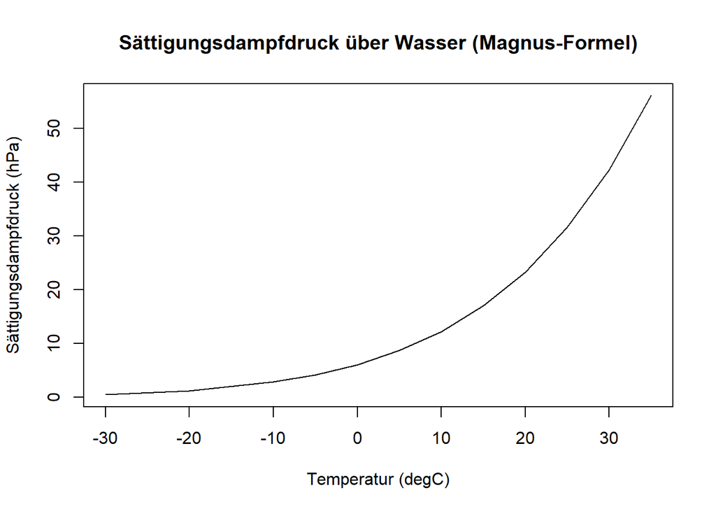

```r
plot(df$temperature, df$saturation,
     type = "l",
     main = "Sättigungsdampfdruck über Wasser (Magnus-Formel)",
     xlab = "Temperatur (degC)",
     ylab = "Sättigungsdampfdruck (hPa)")
```

Mehr dazu in den kommenden Wochen!

# 9 Zu Hilfe!!

```
Hilf mir, es allein zu tun.
```

Dieses Zitat von Maria Montessori trifft natürlich auch auf die Programmierung zu. Hilfe finden, um Probleme zu lösen - das ist sicherlich **die** Schlüsselkompetenz. Nur die wenigstens wissenschaftlichen R-Nutzer sprechen fließend R, sondern stückeln sich ihren Code so gut es geht zusammen.

## 9.1 Hilfe in `RStudio`

In einer R-Umgebung (also auch in RStudio), kann man sich über Funktionen über `help` oder `?` informieren.

```r
# Hilfe zum print-Befehl
help(print)  # oder ?print
```

Wenn Du den `help`-Befehl in der Konsole oder einem R-Skript eingibst, wird Dir die Hilfe im Fenster unten rechts unter dem Reiter `Help` angezeigt. Dort gibt es noch eine weitere Möglichkeit nach Hilfe zu suchen - einfach in der Suchleiste den entsprechenden Befehl eingeben. Wenn Du den `help`-Befehl in einem R-Markdown verwendest, öffnet sich eine HTML-Seite mit der Hilfe.

RStudio bietet aber mehr. Der Schlüssel ist die `Tab`-Taste (Tabulator). Wenn Du einen Befehl eingibst, kannst Du zu jedem Zeitpunkt `Tab` drücken und RStudio bietet Dir dann Optionen an oder vervollständigt den Code. Außerdem kannst Du auch F1 drücken, und die Hilfe zum Befehl unter dem Cursor wird erscheinen.

> Aufgabe 8
> - Gib `pr` ein und drücke dann `Tab`. Was passiert?
> - Gib nun `pri` ein und drücke dann `Tab`. Beobachtung?

Wie Du vielleicht gerade schon gemerkt hast, wird einem so auch Hilfe über den Aufruf einer Funktion angezeigt - also zum Beispiel welche Argumente eine Funktion benötigt.

> Aufgabe 9

> Unter Abschnitt 6 haben wir die Funktion `platform_info()` vom Paket `sessioninfo` verwendet und uns gefragt, wofür `ui` in der Ausgabe steht. Nutze die Hilfefunktionen, um es herauszufinden!

> ```r
> # Hilfe direkt zur Funktion
> help(platform_info, package=sessioninfo)
>
> # Hilfe über das Paket und alle darin enthaltenen Funktionen
> help(package=sessioninfo)
> ```

> In der Hilfe zur Funktion ist unter `Value` aufgeführt, was Dir die Funktion ausgibt - eine Liste mit einer Reihe von Elementen. `ui` steht dabei für das user interface, wie zum Beispiel RStudio.

## 9.2 Hilfe im Netz

RStudio bietet bequemen Zugang zur eingebauten R-Hilfe. Oft löst das aber nicht das Problem zum Verständnis der Funktion oder Lösung eines Problems. Fast genauso oft hatten aber andere Menschen schon das gleiche Problem und sich online Hilfe geholt. Eine der besten Hilfeplattformen ist [stackoverflow](https://stackoverflow.com/). Dort landet man bei einer normalen Websuche nicht selten. Aber es gibt auch andere Plattformen, auf denen man auf Antworten stößt. [rseek.org](https://rseek.org/) ist eine Suchmaschine, die Eure Suche gezielt auf R-Belange einschränkt - “R” allein ist sonst eher ein unglücklicher Suchbegriff.

Suche auf Englisch - so findest Du meist die hilfreicheren Quellen.

## 9.3 Fehler sind eine Hilfe!

Oft erzeugen Fehlermeldungen lange Gesichter. Aber fürchte Dich nicht. Freue Dich, dass R versucht, Deinen Code in Ordnung zu bringen. Wenn Du mit der Fehlermeldung nichts anfangen kannst, kopiere sie einfach in eine Websuche und lasst Dir dort die Lösung servieren.

> Aufgabe 10

> Führe die folgenden Codezeilen aus und überlege, was die Fehlermeldungen Dir sagen. Versuch die Fehler zu korrigieren, sodass der Code ausgeführt wird.

> ```r
> print(Hallo Welt)
> print "Hallo Welt"
> read.table("data/example-file1.txt", sep="\n")
> ```

```r
print(Hallo Welt)
```

```
## Error: <text>:1:13: unerwartetes Symbol
## 1: print(Hallo Welt
##                 ^
```

```r
print "Hallo Welt"
```

```
## Error: <text>:1:7: unerwartete Zeichenkettenkonstante
## 1: print "Hallo Welt"
##           ^
```

In diesen beiden Fällen stimmt die Syntax nicht - beim `print`-Befehl brauchen wir sowohl die Klammern als auch die Anführungszeichen:

```r
print("Hallo Welt")
```

```
## [1] "Hallo Welt"
```

Schauen wir uns die dritte Zeile an:

```r
read.table("data/example-file1.txt", sep="\n")
```

```
## Error in file(file, "rt"): kann Verbindung nicht öffnen
```

R kann die Datei nicht einlesen, da die Pfadangabe und der Dateiname nicht stimmen. So funktioniert es:

```r
read.table("example-file-1.txt", sep="\n")
```

```
##                                                   V1
## 1                                        Hallo Welt!
## 2 (in einer Datei im gleichen Verzeichnis versteckt)
```

# 10 Zum Weiterarbeiten

[Mehr zu RStudio](https://www.earthdatascience.org/courses/earth-analytics/document-your-science/intro-to-r-and-rstudio/)

[Mehr zu R-Markdown](https://www.earthdatascience.org/courses/earth-analytics/document-your-science/intro-to-the-rmarkdown-format-and-knitr/)

[Basic R Syntax](https://www.earthdatascience.org/courses/earth-analytics/time-series-data/basic-r-syntax-scientific-programming/)

# 11 Vertiefung in der Coding-Werkstatt

Bearbeite zunächst die Übungsaufgaben zu dieser Lektion, denn in den Übungsaufgaben wirst Du einen weiteren wichtigen Datentyp in R kennenlernen: den Vektor (vector). Beispiele für Vektoren:

```r
nottodolist = c("Frühzeitig an die eigene Rente denken.",
               "Glastüren übersehen.",
               "Etwas kaufen, weil es »Aloe Vera« enthält.")
ichzaehlbis3 = c(1, 2, 3)
```

```r
# Länge eines Vektors
length(nottodolist)
```

```
## [1] 3
```

```r
# Zugriff auf Elemente eines Vektors
nottodolist[1]
```

```
## [1] "Frühzeitig an die eigene Rente denken."
```

```r
# Schleife über Elemente eines Vektors
for (i in 1:length(nottodolist)){
  print(nottodolist[i])
}
```

```
## [1] "Frühzeitig an die eigene Rente denken."
## [1] "Glastüren übersehen."
## [1] "Etwas kaufen, weil es »Aloe Vera« enthält."
```

Die drei Begriffe “Vektor”, “Array” und “Matrix” werden in R teilweise synonym verwendet. Sie bezeichnen in jedem Fall eine Variable, in der mehr als nur ein Wert steckt (eine Varaible mit nur einem Wert heißt übrigens “skalar”).

Vektoren sind dabei eindimensional, Array und Matrizen können auch mehr Dimensionen beinhalten.

## 11.1 Benannte Vektoren

In dieser Vertiefung lernen wir benannte Vektoren (`named vectors`) kennen. Wie der Begriff vermuten lässt, enthalten diese neben den eigentlichen Werten im Vektor auch noch für jeden Wert einen Namen.

```r
article = c(title = "River flow forecasting through conceptual models part I — A discussion of principles",
            authors = "Nash, J. E., Sutcliffe, J. V.",
            journal = "Journal of Hydrology",
            year = 1970)
```

```r
# Die Elemente kann man wie beim Vektor über Indizes aufrufen
article[3]
```

```
##                journal
## "Journal of Hydrology"
```

```r
# Die Elemente können aber auch über den entsprechenden Namen aufgerufen werden
article["title"]
```

```
##                                                                                  title
## "River flow forecasting through conceptual models part I — A discussion of principles"
```

```r
# Übersicht über alle Namen
names(article)
```

```
## [1] "title"   "authors" "journal" "year"
```

```r
# Hinzufügen neuer Elemente
article["volume"] = 10
article["issue"] = 3
article["firstpage"] = 282
article["lastpage"] = 290

article
```

```
##                                                                                  title
## "River flow forecasting through conceptual models part I — A discussion of principles"
##                                                                                authors
##                                                        "Nash, J. E., Sutcliffe, J. V."
##                                                                                journal
##                                                                 "Journal of Hydrology"
##                                                                                   year
##                                                                                 "1970"
##                                                                                 volume
##                                                                                   "10"
##                                                                                  issue
##                                                                                    "3"
##                                                                              firstpage
##                                                                                  "282"
##                                                                               lastpage
##                                                                                  "290"
```

## 11.2 Jetzt bist Du dran: Erfassung und Abfrage von Radiosonden-Metadaten

Radiosondenaufstiege dienen der vertikalen Vermessung des Zustands der Atmopshäre. Der Deutsche Wetterdienst (DWD) betreibt 14 aktive Stationen, an denen regelmäßig Radiosondenaufstiege erfolgen (die Ballone, an denen die Sonden hängen, [platzen dann in einer bestimmten Höhe](https://de.wikipedia.org/wiki/Radiosonde#Ballone_und_Fallschirme) und die Sonden kommen dann *irgendwo* wieder runter).

Die Metadaten der einzelnen Stationen hält der DWD [hier](https://opendata.dwd.de/climate_environment/CDC/observations_germany/radiosondes/low_resolution/meta_data/) vor. Wir haben für unser Beispiel mal die Metadaten der Station Bergen (Rügen) runtergeladen - Ihr findet Sie im Verzeichnis `../data/Meta_Daten_pkt_aero_00368/` in mehreren Dateien.

Eure Aufgabe besteht nun aus folgenden Schritten:

- **Vektor der Attribute erstellen**: Schaue Dir zunächst die Dateien an. Erstelle nun einen Vektor (`vector`) namens `attributes`, welcher die Bezeichner der Metadatenattribute enthält (z.B. “Stations_ID”)
- **Werte für die einzelnen Attribute eintragen**: Der untenstehende Codeblock fragt Dich nun nach den Werten der Attribute für die Station Bergen. Dazu wird die Funktion `readline` verwendet. Diese Funktion erfordert eine Nutzereingabe und überträgt diese Nutzereingabe auf eine Variable (hier: `value`). Wenn Du also nach dem Wert gefragt wirst, musst Du ihn aus den Dateien ablesen und eintragen. *Hinweis*: Gib immer nur den aktuellen Wert ein, nicht die Historie der Metadaten der Station. **Du musst in dem Codeblock nun noch eine Zeile ergänzen, so dass `value` auch wirklich in den benannten Vektor `metadata` übertragen wird.** Natürlich ist dieses Skript nur dazu da, um Möglichkeiten für Nutzereingaben zu demonstrieren. Du könntest alternativ auch direkt die Definition des `metadata`-Vektors aufschreiben.
- **Benannten Vektor anschauen**: Schau Dir den Zustand Eures Vektors `metadata` an.
- **Werte ausgewählter Attribute ausgeben**: Dieser Codeblock zeigt Dir die verfügbaren Attribute in `metadata` an und erlaubt es Dir, ein Attribut Deiner Wahl anzugeben. Für dieses wird dann der Wert ausgegeben.

### 11.2.1 Vektor der Attribute erstellen

```r
# Definiere hier den Vektor mit Attributen
attributes =
```

### 11.2.2 Werte für die einzelnen Attribute eintragen

```r
# Dies ist der benannte Vektor, in dem die Werte der Attribute gesammelt werden - noch ist er leer...
metadata = vector()

# Nun gehen wir alle Attribute aus attributes durch...
for (attribute in attributes){
  value = readline(paste("Geben Sie einen Wert für", attribute, "ein: "))

  # HIER MUSST Du EINE ZEILE ERGÄNZEN!

}
```

### 11.2.3 Benannten Vektor anschauen

```r
# Was musst Du hier eintragen, um Dir den benannten Vektor anzuschauen?
```

### 11.2.4 Werte ausgewählter Attribute ausgeben

```r
print("Folgende Attribute stehen zur Verfügung:")
for (attribute in names(metadata)){
  print(paste0(" - ", attribute))
}

attribute = readline("Über welches Attribut möchtest Du Dich informieren? ")

print("")
print("---")
print(paste0("Ergebnis der Abfrage für Attribut ", attribute, ":"))

# Hier musst Du nun ein weiteres print-statement einfügen,
# mit dem der Wert dieses Attributs ausgedruckt wird:
```